# Data visualization

Ethan Weed

November 24, 2026

# A short history

## John Snow’s cholera map

[figure not shown]

John Snow’s 1854 map of cholera deaths

## Data visualization is a modern invention

**William Playfair** (1759–1823)

- millwright, engineer, draftsman, accountant, inventor, silversmith, merchant, investment broker, economist, statistician, pamphleteer, translator, publicist, land speculator, banker, ardent royalist, de facto intelligence officer, convict, editor, blackmailer and journalist (Wikipedia)
- Founder of statistical graphics
- inventor of the bar graph, the pie chart, and the line chart

[figure not shown]

## Edward Tufte

[figure not shown]

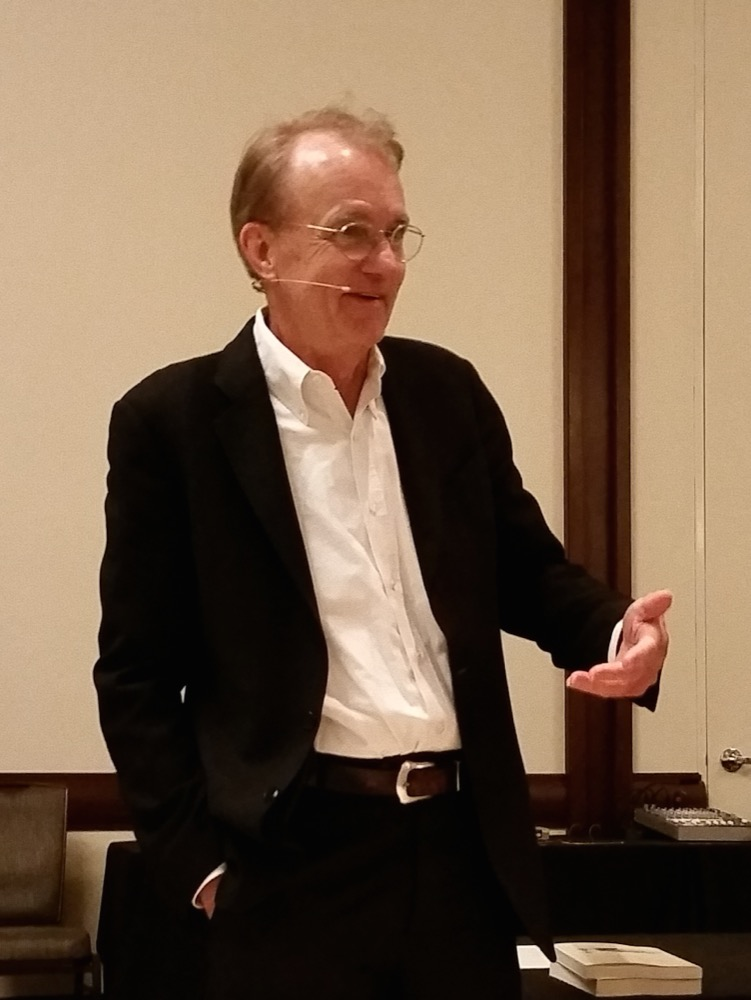

Photo: Keegan Peterzell, CC BY-SA 4.0, via Wikimedia Commons

Tufte (2001)

## Tufte’s Key concepts

- Graphics *reveal* data
- Graphics tell a *story*
- Lie factor
- Data-ink ratio
- Data density
- Revision

# What graphics do

## Graphics *reveal* data

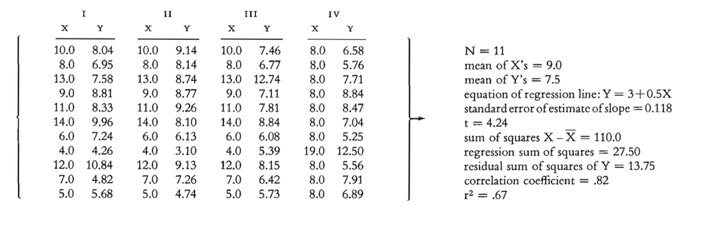

[interactive chart not shown]

Anscombe’s quartet (Anscombe, 1973)

## Datawug

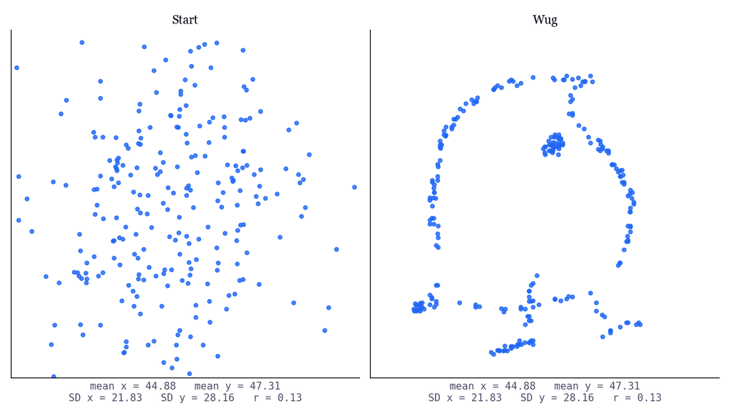

## Garbage in, garbage out

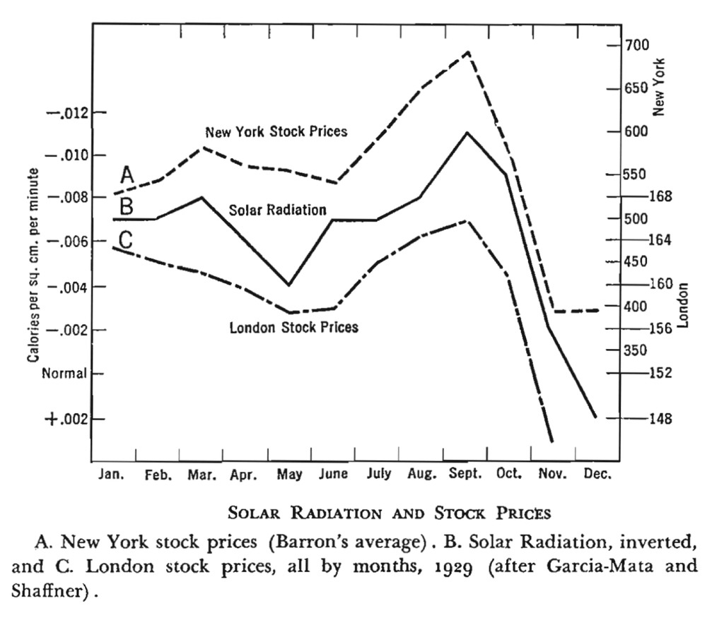

Tufte (2001)

## Garbage in, garbage out

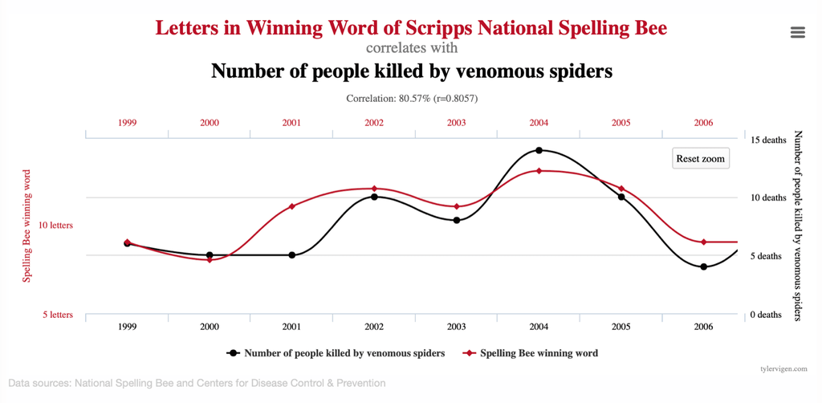

r = 0.80 (“strong”) (Vigen, 2015)

## Graphics tell a *story*

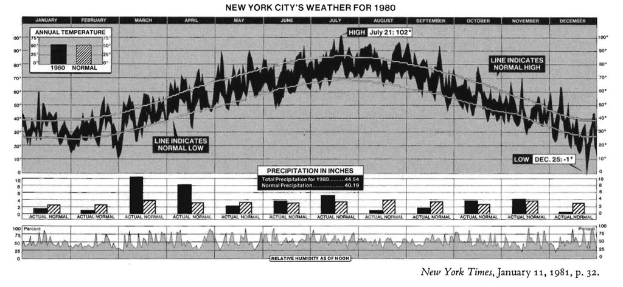

A picture speaks 1888 numbers (Tufte, 2001)

## Four variables, one picture

- Size of the army
- Location
- Direction of movement
- Temperature during the retreat

## Best and worst

> “It may well be the best statistical graphic ever drawn”

[figure not shown]

> “It may well be the worst graphic ever to find its way into print”

Tufte (2001)

## The worst graphic ever

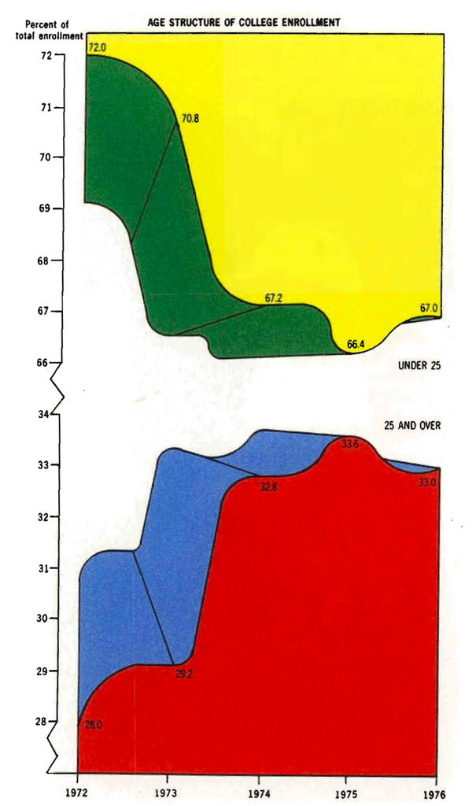

# What makes a good graphic?

## Most information, least time

[figure not shown]

Tufte (2001)

## A good graphic is truthful

[figure not shown]

Tufte (2001)

## No y-axis labels

[figure not shown]

[figure not shown]

Notopoulos (2014)

## Very selective y-axis labels

[figure not shown]

[figure not shown]

Notopoulos (2014)

## Again, no y-axis labels

[figure not shown]

[figure not shown]

Notopoulos (2014)

## What is the story here?

[figure not shown]

[figure not shown]

Danmarks Statistik (2021)

## Tufte’s five principles

- Above all else show the data
- Maximize the data-ink ratio
- Erase non-data ink
- Erase redundant data-ink
- Revise and edit

Tufte (2001)

## Maximize data density

[figure not shown]

## Low data density

[figure not shown]

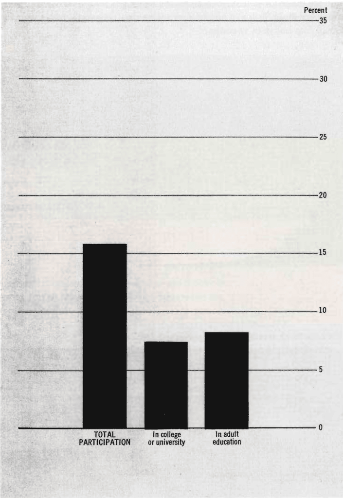

0.02 numbers per cm² (Tufte, 2001)

## High data density

[figure not shown]

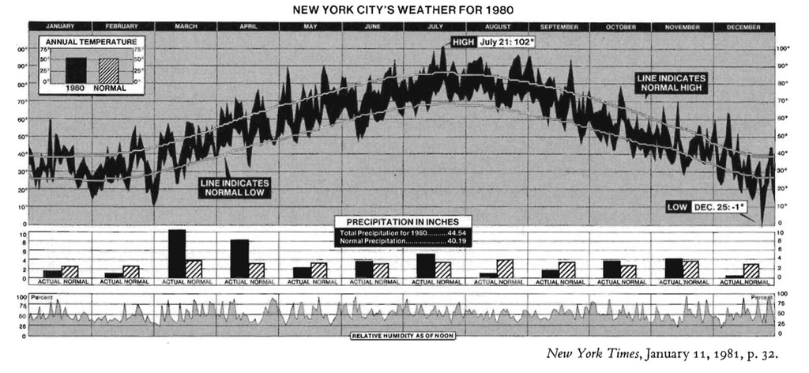

28 numbers per cm²

## Revision

[figure not shown]

Playfair (1785)

[figure not shown]

Playfair (1786)

# Plotting paired data

## Fake data: a Stroop-like experiment

```python
import numpy as np, pandas as pd
import seaborn as sns
import pingouin as pg

rng = np.random.default_rng(11)
n = 20
base = rng.normal(600, 80, n)   # subjects differ a lot
incon = base + rng.normal(0, 20, n)
con = base - 30 + rng.normal(0, 20, n)  # small, consistent effect

df = pd.DataFrame({"subject": range(n),
                   "Congruent": con,
                   "Incongruent": incon})
# long format: one row per observation
long = df.melt("subject", var_name="condition",
               value_name="rt")

pg.ttest(df.Incongruent, df.Congruent, paired=True)
```

- 20 participants
- Each sees **both** conditions
- Paired *t*-test: *t*(19) = 4.90, *p* < .001
- Mean difference = 23 ms

## Don’t do this

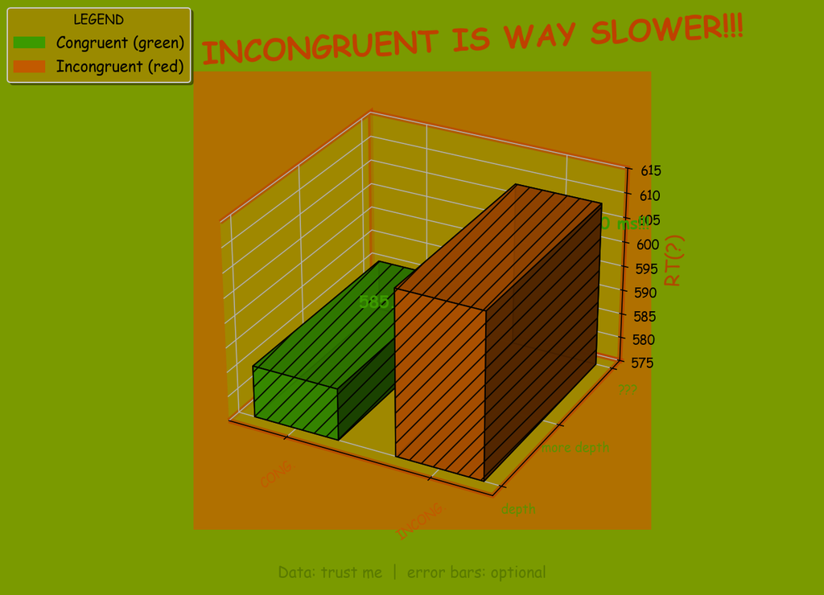

## Bar plot

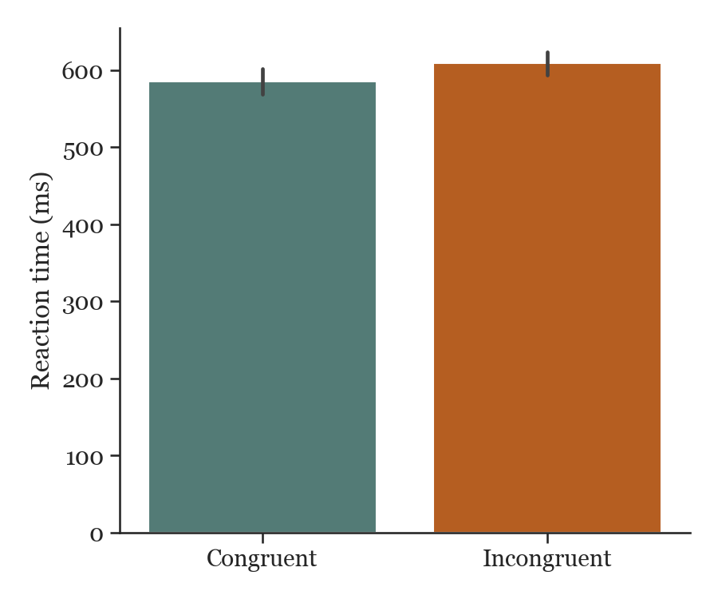

Means ± SE. Low data density

```python
pal = {"Congruent": "#4C827B", "Incongruent": "#CD5909"}

sns.barplot(long, x="condition", y="rt",
            hue="condition", palette=pal,
            errorbar="se")
```

## Bar plot, zoomed in

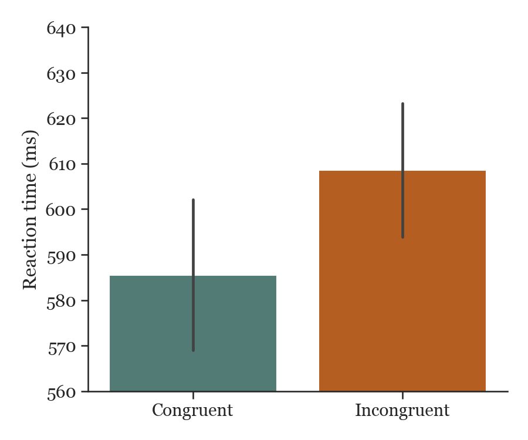

Same data. Lie factor?

```python
pal = {"Congruent": "#4C827B", "Incongruent": "#CD5909"}

ax = sns.barplot(long, x="condition", y="rt",
                 hue="condition", palette=pal,
                 errorbar="se")
ax.set(ylim=(560, 640))
```

## Box plot

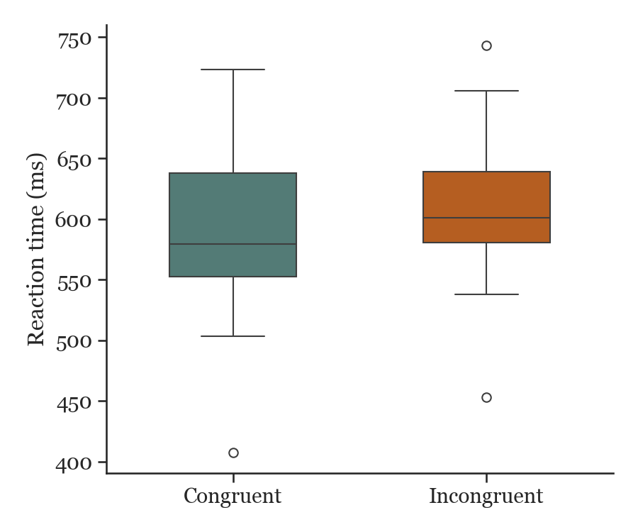

Shows distributions, but hides within-participant effects

```python
pal = {"Congruent": "#4C827B", "Incongruent": "#CD5909"}

sns.boxplot(long, x="condition", y="rt",
            hue="condition", palette=pal,
            width=0.5)
```

## Violin + strip plot

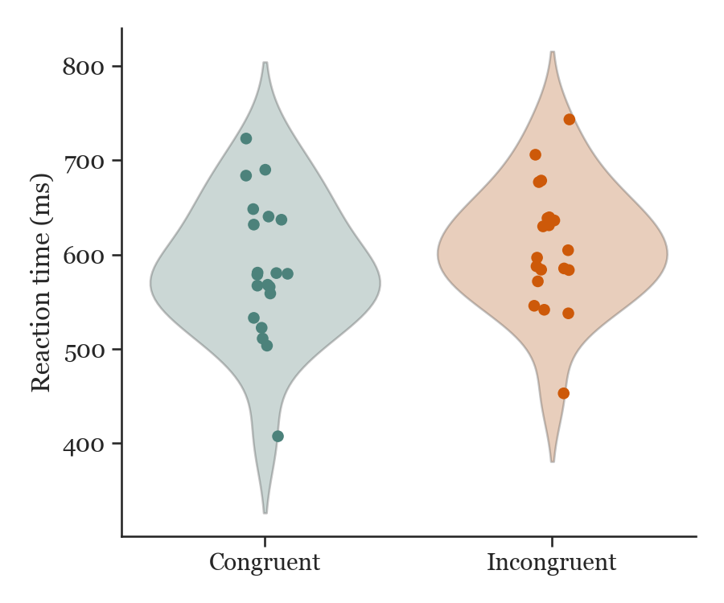

All the data, but also hides within-participant differences

```python
pal = {"Congruent": "#4C827B", "Incongruent": "#CD5909"}

sns.violinplot(long, x="condition", y="rt",
               hue="condition", palette=pal,
               inner=None, alpha=0.3)
sns.stripplot(long, x="condition", y="rt",
              hue="condition", palette=pal,
              size=7, jitter=0.08)
```

## Paired lines

```python
pal = {"Congruent": "#4C827B", "Incongruent": "#CD5909"}

# one grey line per subject
sns.lineplot(long, x="condition", y="rt",
             units="subject", estimator=None,
             color="#9ca0b0", lw=1)
sns.stripplot(long, x="condition", y="rt",
              hue="condition", palette=pal,
              size=7, jitter=False)
# group means ± SE
sns.pointplot(long, x="condition", y="rt",
              color="black", errorbar="se",
              markers="D")
```

[output not shown]

Now the pairing is visible: most lines go up

## Paired lines, with and without violins

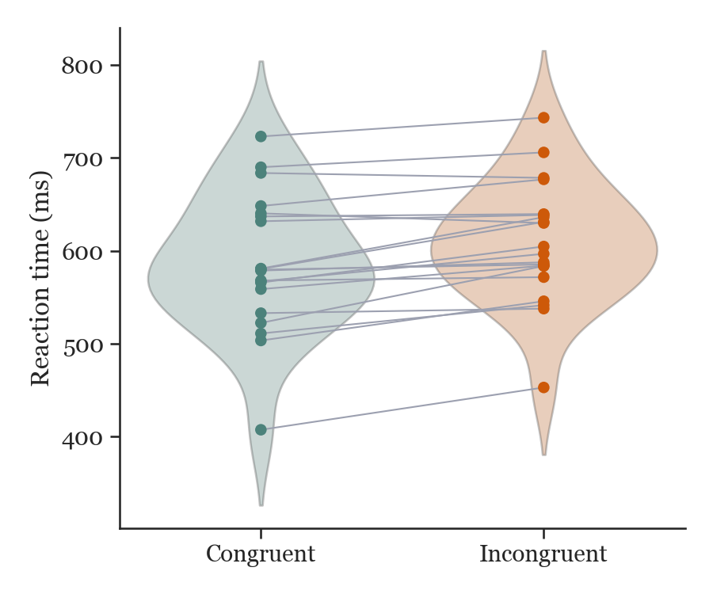

**Code for violin + lines**

```python
sns.violinplot(long, x="condition", y="rt",
               hue="condition", palette=pal,
               inner=None, alpha=0.3)
sns.lineplot(long, x="condition", y="rt",
             units="subject", estimator=None,
             color="#9ca0b0", lw=1)
sns.stripplot(long, x="condition", y="rt",
              hue="condition", palette=pal,
              size=7, jitter=False)
```

## Three ways to show the pairing

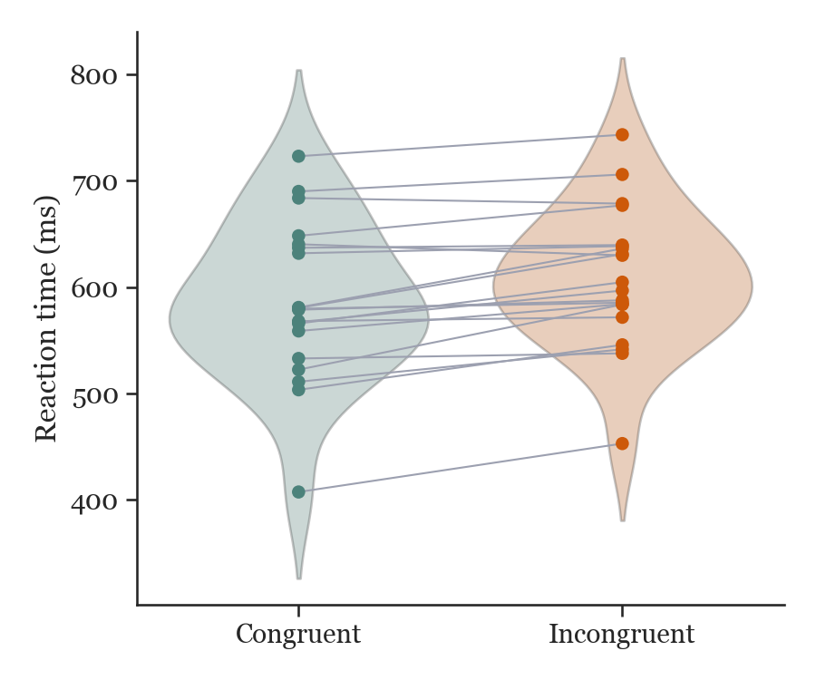

Violin + lines

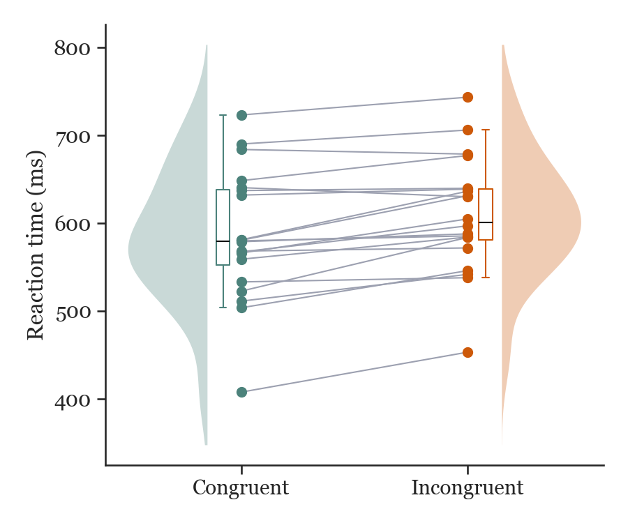

Raincloud

## Scatter against the identity line

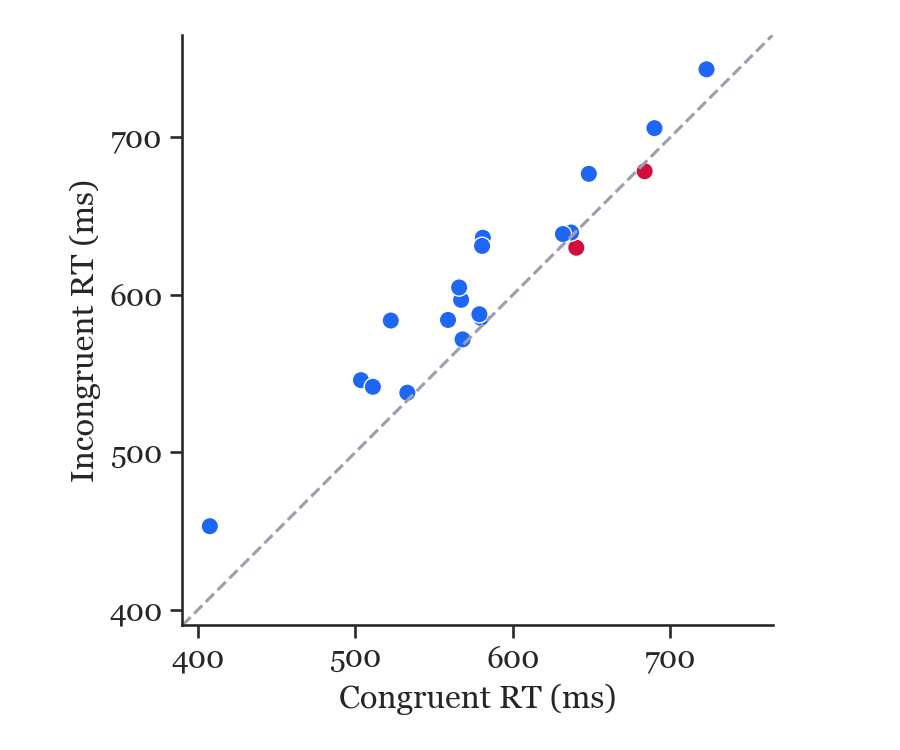

Points above the line: slower when incongruent

```python
below = df.Incongruent < df.Congruent
ax = sns.scatterplot(df, x="Congruent",
                     y="Incongruent", hue=below,
                     palette={False: "#1e66f5",
                              True: "#d20f39"},
                     s=70, legend=False)
lo, hi = 390, 765
ax.plot([lo, hi], [lo, hi],
        color="#9ca0b0", ls="--")   # y = x
ticks = range(400, 800, 100)
ax.set(xlim=(lo, hi), ylim=(lo, hi),
       xticks=ticks, yticks=ticks,
       aspect="equal")
```

## Difference scores

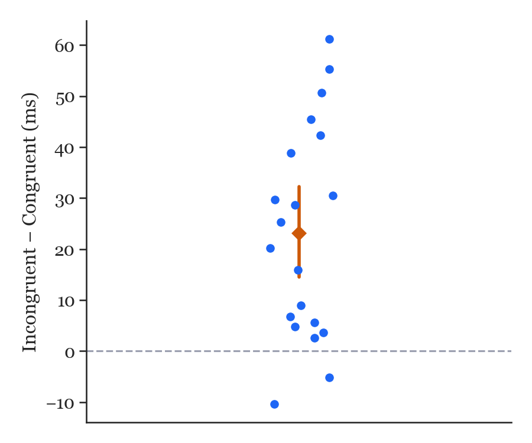

What the paired t-test actually tests, but maybe less intuitive to read?

```python
diff = df.Incongruent - df.Congruent

sns.stripplot(y=diff, color="#1e66f5",
              size=7, jitter=0.08)
# mean difference with 95% CI
ax = sns.pointplot(y=diff, color="#CD5909",
                   errorbar=("ci", 95),
                   markers="D")
ax.axhline(0, color="#9ca0b0", ls="--")
```

# Reading figures

## Which test?

| Test | When to use it |
| --- | --- |
| Paired *t*-test | Two conditions, **same** participants in both; continuous outcome |
| Independent *t*-test | Two groups of **different** participants; continuous outcome |
| One-way ANOVA | Three or more groups (one factor); continuous outcome |
| Two-way ANOVA | Two factors at once; tests each main effect and their interaction |
| Linear regression | Continuous outcome predicted by one or more continuous (or categorical) predictors |
| Logistic regression | Binary outcome (0/1, yes/no, correct/incorrect) predicted by one or more continuous (or categorical) predictors |